# R Notebook

## Introducción

- **Relevancia:** La salud mental es el equilibrio entre nosotros, nuestro entorno y nuestro bienestar emocional, psicológico y social, esto nos afecta a la forma en que pensamos, sentimos y actuamos en el día a día. De a cuerdo con el MINEDU en promedio el 85% de la comunidad educativa superior presenta algún problema de salud mental, siendo el estrés y la ansiedad los más habituales. En el caso de los jóvenes universitarios es un tema de suma importancia que tiene consecuencias directas en el ámbito académico que no siempre se le da la relevancia requerida. Es por esta razón que con los datos obtenidos se desea averiguar la relación entre nuestras distintas variables y su efecto sobre el rendimiento académico de los alumnos.
- **Planificación:**

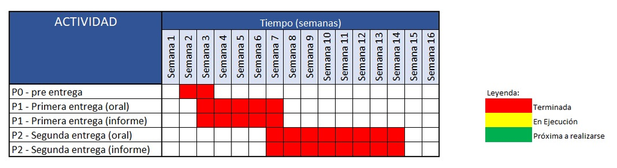

## Datos

- **Recolección de datos :**
  - **¿Cómo se obtuvo los datos y por qué se hizo de esa manera? :**

  Para el proceso de recolección de datos se optó por obtener los datos mediante una encuesta, pues era mucho más factible obtener respuestas de diversos estudiantes universitarios de diversas carreras e instituciones universitarias y llegar a los mismos por medio de esta modalidad. Para la recolección de datos se entregó la encuesta a amigos y compañeros de cada uno de los integrantes de este grupo para así obtener la mayor cantidad de respuestas posibles
  - **Condiciones para la recolección de datos**

  Las condiciones para la recolección fueron que los entrevistados sean estudiantes universitarios de primer a décimo ciclo de distintas universidades y carreras.
  - **Estrategias para llegar a la población**

*1. Corregir nombre de las variables* Primero se analizarán los nombres de la base de datos para cambiarlos o corregirlos posteriormente :

```r
names(P2)
```

```
##  [1] "Marca temporal"
##  [2] "Dirección de correo electrónico"
##  [3] "Sexo"
##  [4] "Ciclo de Estudios"
##  [5] "Carrera"
##  [6] "¿Sabes que es la salud mental?"
##  [7] "¿En algún momento recibiste o pensaste que necesitabas recibir ayuda profesional de algún psicólogo?"
##  [8] "Del 1 al 5 ¿Cuánto crees que la universidad afecta tu salud mental?"
##  [9] "¿Cuándo sientes que tienes problemas de salud mental, con quién acudes?"
## [10] "¿Sabes si tu universidad cuenta con buenos recursos que garanticen tu bienestar emocional?"
## [11] "Del 1 al 5 ¿Cuánto crees que problemas como la ansiedad/estrés/depresión afecten a tu rendimiento académico?"
## [12] "Del 1 al 5 ¿Consideras que el apoyo de tu entorno influye en tu motivación para esforzarte en todo aspecto de tu vida?"
## [13] "¿Tienes amigos/compañeros/familiares que apoyen las decisiones que tomas?"
## [14] "Del 1 al 7 ¿Cuántas veces a la semana presentas problemas para conciliar el sueño?"
## [15] "¿Tienes la necesidad de evitar las situaciones que generan ansiedad?"
```

Se nota que hay variables con nombre erróneo y que deben cambiarse por una mejor redacción, por lo tanto se asigna un mejor nombre a las variables en forma de preguntas, teniendo en cuenta que las tildes o caracteres especiales no son leídas por *Rstudio*.

Nombres a reemplazar para cada variable :

- “Sexo” → “Género”
- “¿Sabes que es la salud mental?” → “Conocimiento de la salud mental”
- “¿En algún momento recibiste o pensaste que necesitabas recibir ayuda profesional de algún psicólogo?” → “Evaluación de asesoría psicológica”
- “Del 1 al 5 ¿Cuánto crees que la universidad afecta tu salud mental?” → “Nivel de efecto en la salud mental por la universidad”
- “¿Cuando sientes que tienes problemas de salud mental, con quién acudes?” → “Fuente de Soporte Emocional”
- “¿Sabes si tu universidad cuenta con buenos recursos que garanticen tu bienestar emocional?” → “Conocimiento de herramientas dadas por la universidad”
- “Del 1 al 5 ¿Cuánto crees que problemas como la ansiedad/estrés/depresión afecten a tu rendimiento académico?” → “Nivel de Efecto de la salud mental en el rendimiento académico”
- “Del 1 al 5 ¿Consideras que el apoyo de tu entorno influye en tu motivación para esforzarte en todo aspecto de tu vida?” → “Nivel de apoyo del entorno”
- “¿Tienes amigos/compañeros/familiares que apoyen las decisiones que tomas?” → “Apoyo Personal hacia los estudiantes”
- “Del 1 al 7 ¿Cuántas veces a la semana presentas problemas para conciliar el sueño?” → “Días de falta de sueño a causa de la salud mental”
- “¿Tienes la necesidad de evitar las situaciones que generan ansiedad?” → “Ansiedad”

Se utilizará el comando `rename` para así cambiar el nombre respectivamente, para esto se cargará la librería `dplyr`

```r
P2_limpia <-rename(P2, "Genero" = 'Sexo',"Conocimiento de la salud mental" = '¿Sabes que es la salud mental?',"Evaluación de asesoría psicológica" = '¿En algún momento recibiste o pensaste que necesitabas recibir ayuda profesional de algún psicólogo?', "Nivel de efecto en la salud mental por la universidad" = 'Del 1 al 5 ¿Cuánto crees que la universidad afecta tu salud mental?',"Fuente de Soporte Emocional"='¿Cuándo sientes que tienes problemas de salud mental, con quién acudes?', "Conocimiento de herramientas dadas por la universidad" = '¿Sabes si tu universidad cuenta con buenos recursos que garanticen tu bienestar emocional?',"Nivel de Efecto de la salud mental en el rendimiento académico" = 'Del 1 al 5 ¿Cuánto crees que problemas como la ansiedad/estrés/depresión afecten a tu rendimiento académico?' ,"Nivel de apoyo del entorno" = 'Del 1 al 5 ¿Consideras que el apoyo de tu entorno influye en tu motivación para esforzarte en todo aspecto de tu vida?', "Apoyo Personal hacia los estudiantes"='¿Tienes amigos/compañeros/familiares que apoyen las decisiones que tomas?',  "Días de falta de sueño a causa de la salud mental" = 'Del 1 al 7 ¿Cuántas veces a la semana presentas problemas para conciliar el sueño?',"Ansiedad" = '¿Tienes la necesidad de evitar las situaciones que generan ansiedad?' )
```

# 2. Eliminar Variables innecesarias

```r
names(P2_limpia)
```

```
##  [1] "Marca temporal"
##  [2] "Dirección de correo electrónico"
##  [3] "Genero"
##  [4] "Ciclo de Estudios"
##  [5] "Carrera"
##  [6] "Conocimiento de la salud mental"
##  [7] "Evaluación de asesoría psicológica"
##  [8] "Nivel de efecto en la salud mental por la universidad"
##  [9] "Fuente de Soporte Emocional"
## [10] "Conocimiento de herramientas dadas por la universidad"
## [11] "Nivel de Efecto de la salud mental en el rendimiento académico"
## [12] "Nivel de apoyo del entorno"
## [13] "Apoyo Personal hacia los estudiantes"
## [14] "Días de falta de sueño a causa de la salud mental"
## [15] "Ansiedad"
```

Luego de corregir el nombre de las variables, se tendrá que eliminar las variables **Marca temporal** y **Dirección de correo electrónico**, pues estas no aportan a nada a la investigación, para eso utilizaremos el comando `select` de la librería dplyr.

```r
P2_limpia <- select(P2_limpia, 'Genero':'Ansiedad')
```

[output not shown]

# Análisis descriptivo de una variable

Se analizarán las variables relevantes del estudio en términos de sus descriptores gráficos o numéricos, dependiendo del tipo de variable. El fin del análisis es demostrar algún comportamiento relevante en el estudio.

## Género

- Tipo de variable: **Categórica**
- Descriptor gráfico: **Gráfico de barras**

La variable **Género** al ser una variable **categórica** se deberá analizar mediante un gráfico de barras, para ello se utilizará el comando `barplot`

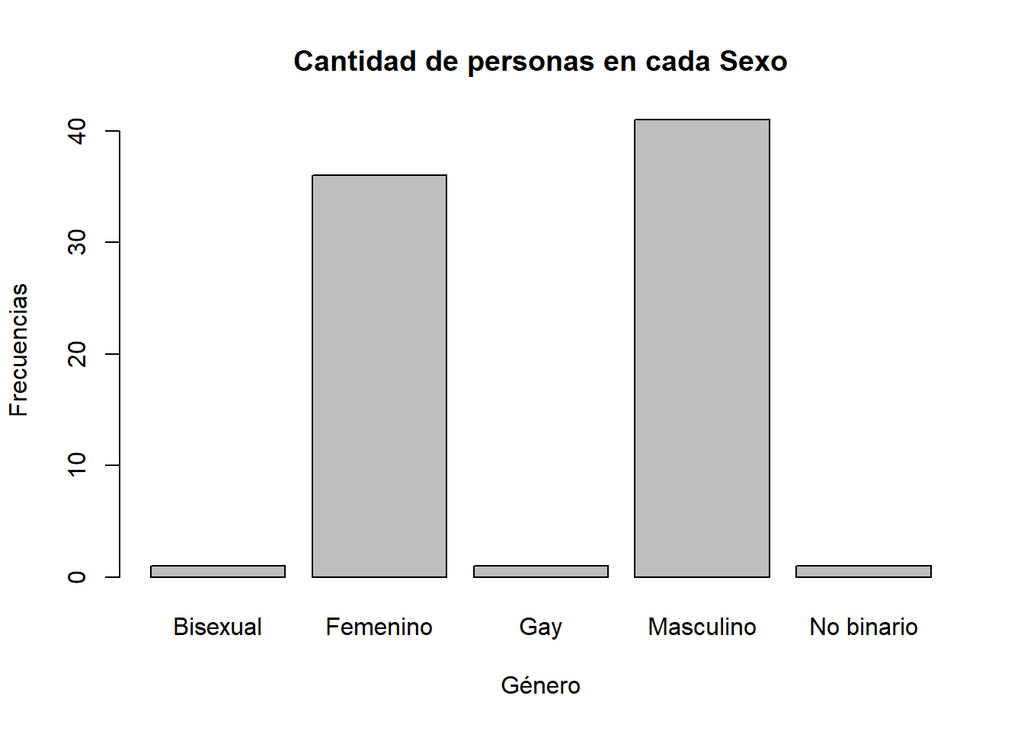

Información obtenida por la gráfica:

```
Mediante el gráfico de barras podemos determinar la cantidad de personas de cada género que han sido participes de la encuesta o estudio, viendo así que presentamos más cantidad de personas que se identifican como género masculino.
```

## Ciclo de Estudios

- Tipo de variable: **Categórica**
- Descriptor gráfico: **Gráfico de barras**

La variable **Ciclo de Estudios** al ser una variable **categórica** se deberá analizar mediante un gráfico de barras, para ello se utilizará el comando `barplot`

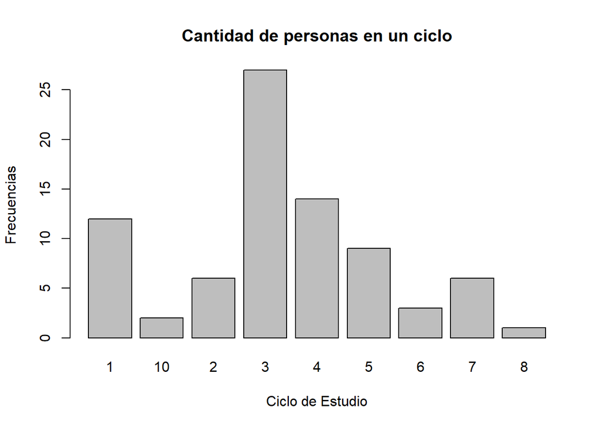

Información obtenida por la gráfica:

```
Mediante el gráfico de barras podemos determinar la cantidad de personas que cursan cada ciclo desde el 1° hasta el 10° y que han sido participes de la encuesta o estudio, viendo así que presentamos más cantidad de personas que pertenecen al 3er ciclo.
```

## Conocimiento de la salud mental

- Tipo de variable: **Categórica**
- Descriptor gráfico: **Gráfico de barras**

La variable **Conocimiento de la salud mental** al ser una variable **categórica** se deberá analizar mediante un gráfico de barras, para ello se utilizará el comando `barplot`

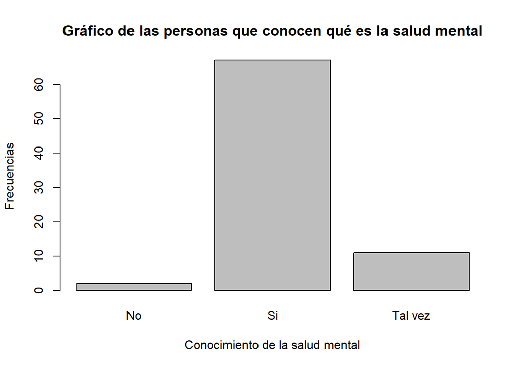

Información obtenida por la gráfica:

```
Mediante el gráfico de barras podemos determinar la cantidad de personas que conocen acerca de la salud mental que la gran mayoría de estudiantes universitarios conocen de la existencia del término Salud mental
```

## Evaluación de asesoría psicológica

- Tipo de variable: **Categórica**
- Descriptor gráfico: **Gráfico de barras**

La variable **Evaluación de asesoría psicológica** al ser una variable **categórica** se deberá analizar mediante un gráfico de barras, para ello se utilizará el comando `barplot`

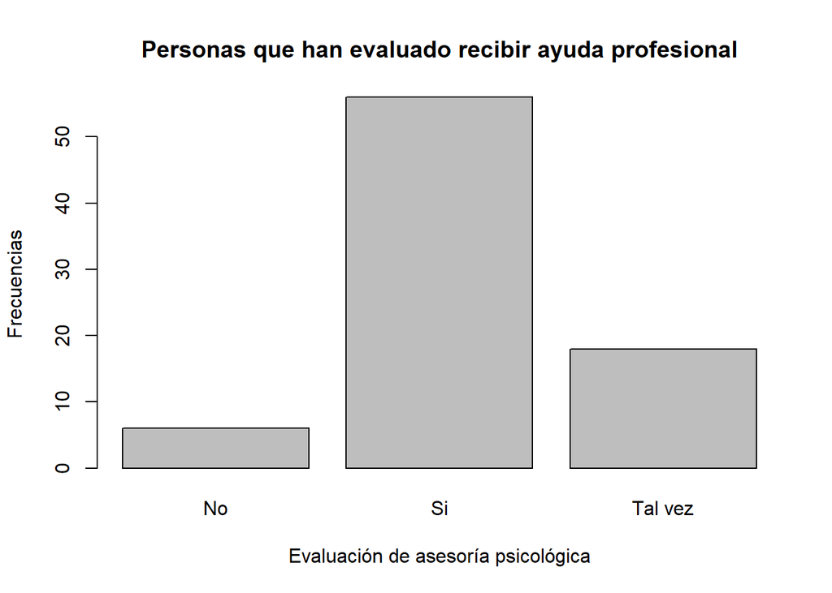

Información obtenida por la gráfica:

```
Mediante el gráfico de barras podemos determinar la cantidad de estudiantes que han evaluado recibir ayuda de algún psicólogo profesional, siendo así, que más de 50 estudiantes lo han evaluado.
```

## Nivel de efecto en la salud mental por la universidad

- Tipo de variable: **Categórica**
- Descriptor gráfico: **Gráfico de barras**

La variable **Nivel de efecto en la salud mental por la universidad** al ser una variable **categórica** se deberá analizar mediante un gráfico de barras, para ello se utilizará el comando `barplot`

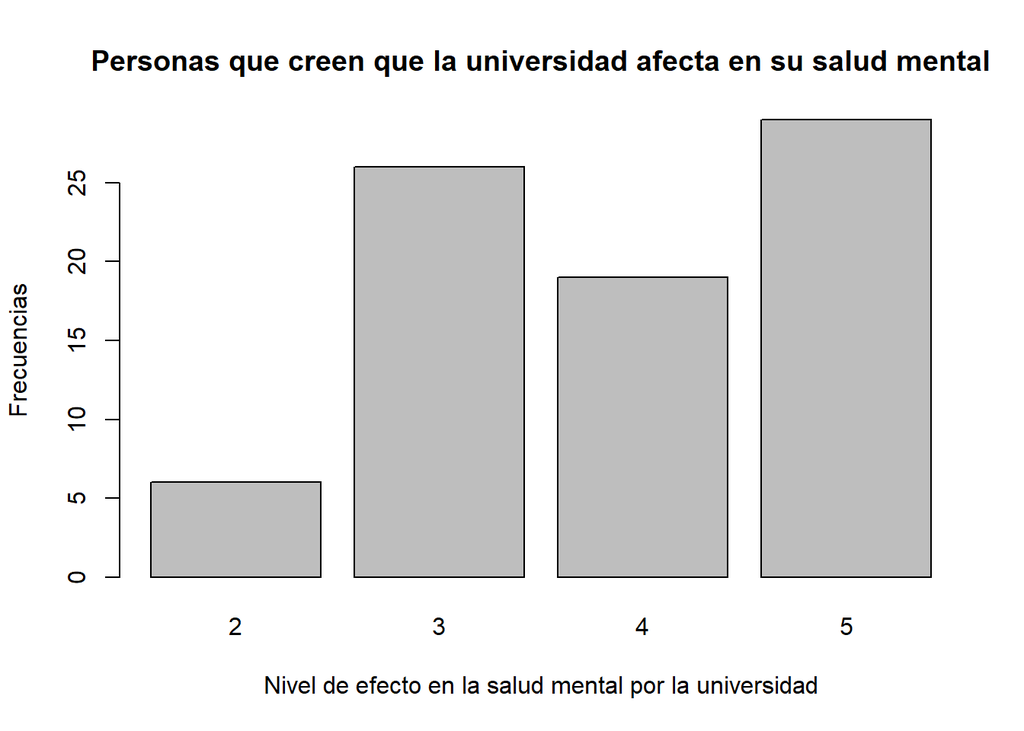

Información obtenida por la gráfica:

```
Mediante el gráfico de barras podemos determinar que una gran cantidad de personas creen que la universidad afecta en su salud mental.
```

## Fuente de soporte Emocional

- Tipo de variable: **Categórica**
- Descriptor gráfico: **Gráfico de barras**

La variable **Fuente de soporte emocional** al ser una variable **categórica** se deberá analizar mediante un gráfico de barras, para ello se utilizará el comando `barplot`

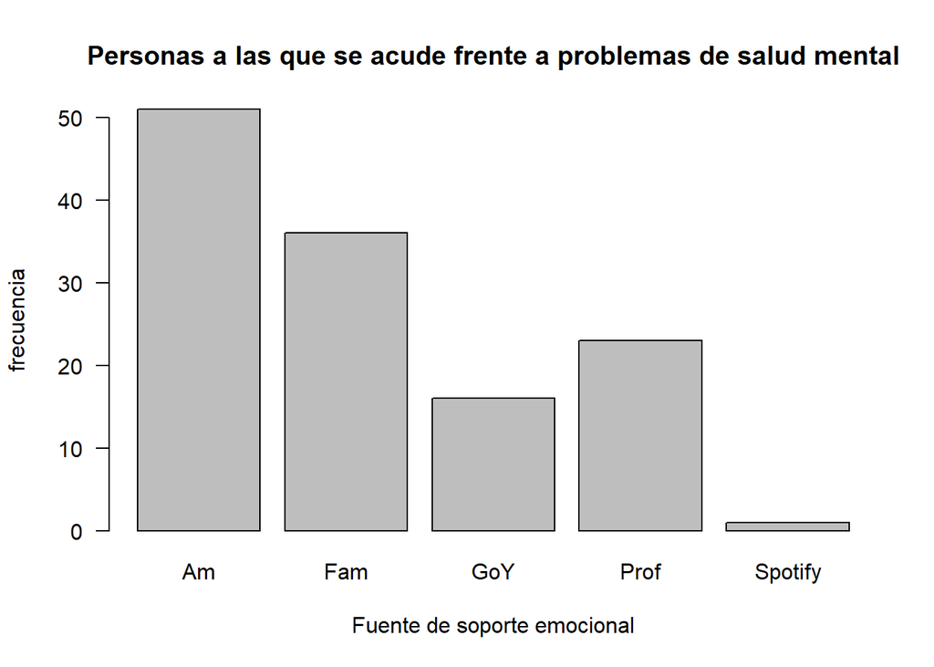

Información obtenida por la gráfica:

```
Mediante el gráfico de barras podemos determinar que una gran la mayoría de estudiantes prefieren acudir más a sus amigos que a sus famliares o buscar la ayuda de un profesional.
```

## Conocimiento de herramientas dadas por la universidad

- Tipo de variable: **Categórica**
- Descriptor gráfico: **Gráfico de barras**

La variable **Conocimiento de herramientas** al ser una variable **categórica** se deberá analizar mediante un gráfico de barras, para ello se utilizará el comando `barplot`

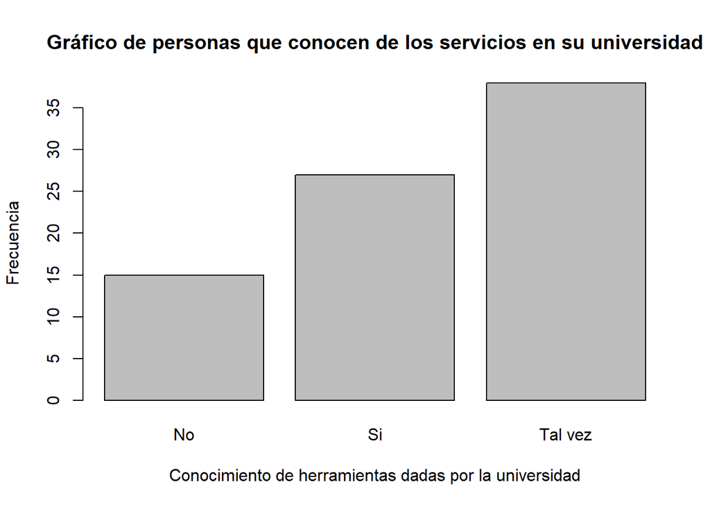

Información obtenida por la gráfica:

[output not shown]

## Nivel de Efecto de la salud mental en el rendimiento académico

- Tipo de variable: **Categórica**
- Descriptor gráfico: **Gráfico de barras**

La variable **Nivel de efecto de la salud mental en el rendimiento académico** al ser una variable **categórica** se deberá analizar mediante un gráfico de barras, para ello se utilizará el comando `barplot`

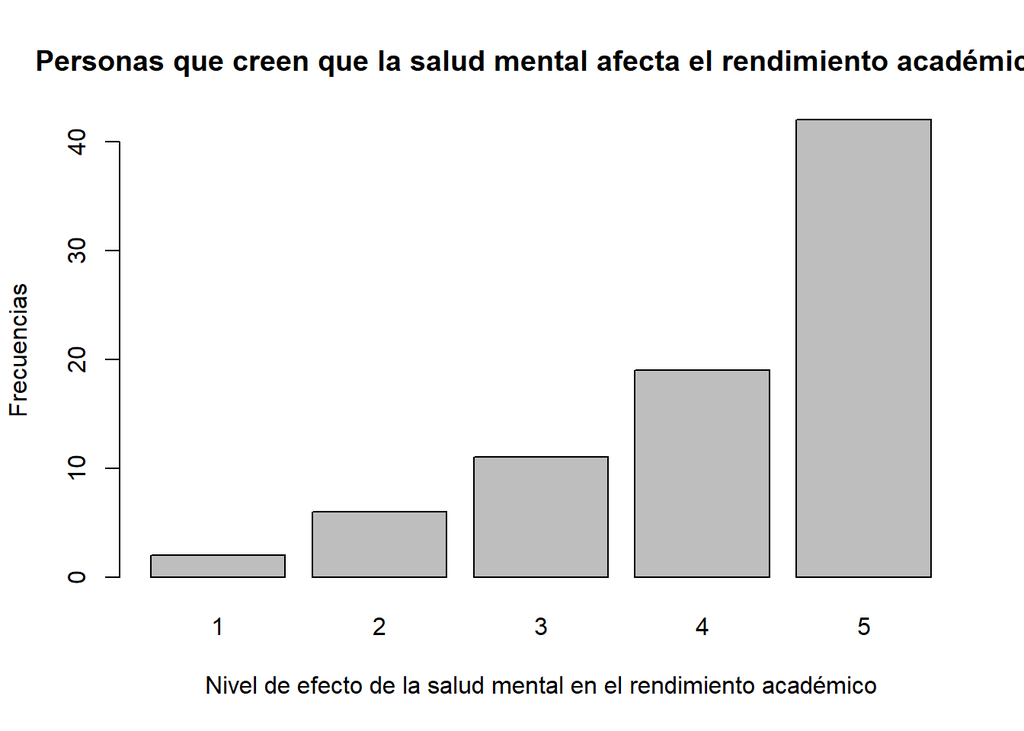

Información obtenida por la gráfica:

[output not shown]

## Nivel de apoyo del entorno

- Tipo de variable: **Categórica**
- Descriptor gráfico: **Gráfico de barras**

La variable **Nivel de apoyo del entorno** al ser una variable **categórica** se deberá analizar mediante un gráfico de barras, para ello se utilizará el comando `barplot`

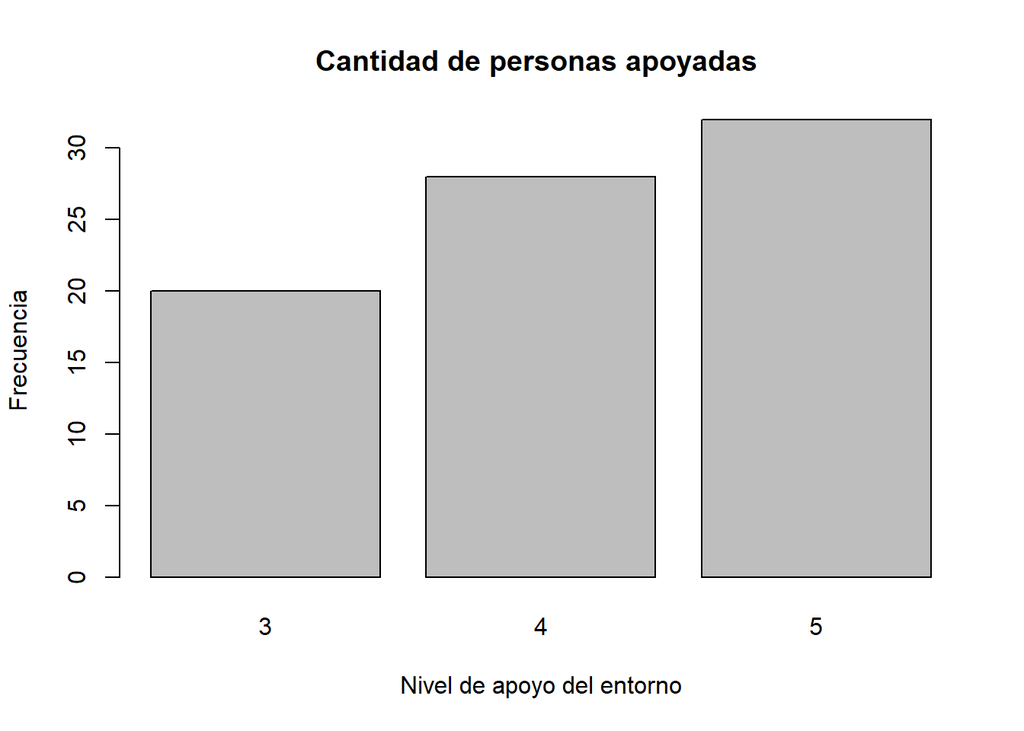

Información obtenida por la gráfica:

```
Mediante el gráfico de barras podemos determinar una gran mayoría de personas afirman que el entorno les motiva en algunas áreas de su vida
```

## Apoyo Personal hacia los estudiantes

- Tipo de variable: **Categórica**
- Descriptor gráfico: **Gráfico de barras**

La variable **Apoyo personal hacia los estudiantes** al ser una variable **categórica** se deberá analizar mediante un gráfico de barras, para ello se utilizará el comando `barplot`

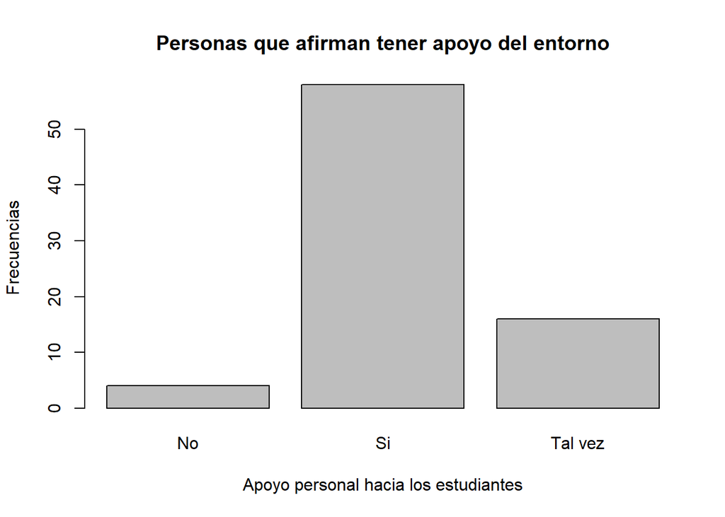

Información obtenida por la gráfica:

```
Mediante el gráfico de barras podemos determinar una gran mayoría de personas afirman tener amigos/compañeros/familiares que apoyen las decisiones que toman
```

## Días de falta de sueño a causa de la salud mental

- Tipo de variable: **Numérica discreta**
- Descriptor numérico: **Promedio, mediana, cuantiles, mínimo y máximo**
- Descriptor gráfico : **Gráfico de caja**

La variable **Días de falta de sueño a causa de la salud mental** al ser una variable **Numérica** se deberá analizar mediante descriptores de posición, para ello se utilizará el comando `summary` y para analizarlo gráficamente se utilizará el comando `boxplot`

```
##    Min. 1st Qu.  Median    Mean 3rd Qu.    Max.    NA's
##    1.00    2.00    4.00    3.81    5.00    7.00       1
```

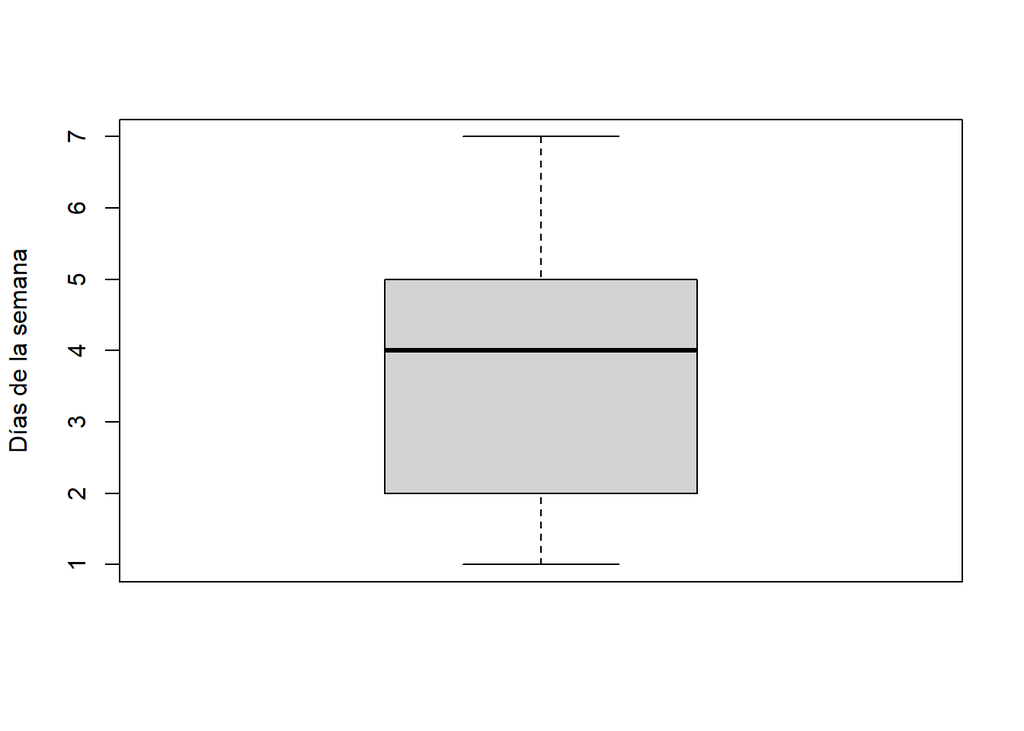

Información obtenida por los descriptores:

```
Mediante los descriptores de posición podemos afirmar que en promedio los alumnos no pueden lograr dormir 3.81  días
```